# Gibbon Analysis

Cal

22/06/2017

# Abstract

# Looking at the data:

```r
library('DEVDEV5') # load the development version of the LT2D package
Data = read.csv('GibbonSiamang.csv',header=T) # load the x and y data
Data = subset(Data, Data$Species == 1)
x = Data$PP.Distance ; y = Data$Forward.Distance
```

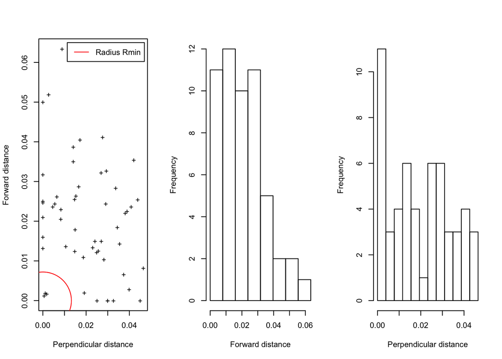

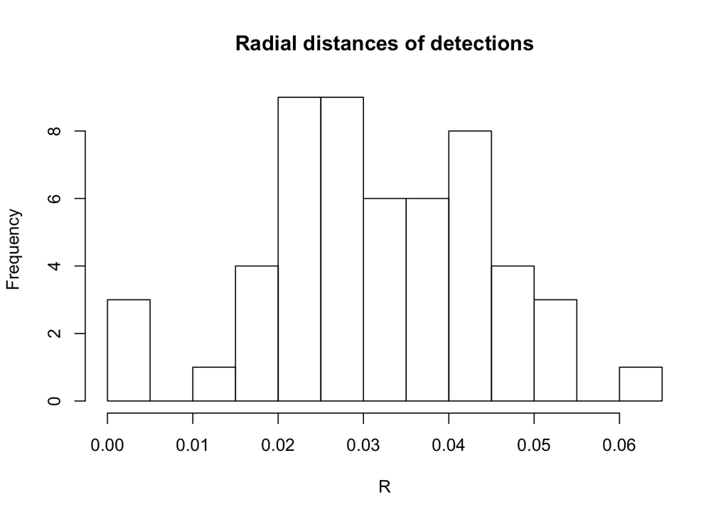

It would seem by inspection, that 0.05 seems a reasonable perpendicular truncation distance ($w=0.05$), and 0.065 seems reasonable for $ystart$; the furthest forward distance at which we are able to detect animals. We have a small cluster of values at distances close to (0,0), which is likely due to the rounding of recorded values in the field. Points at these coordinates have had a small amount of noise added to them in the scatter plot, to make the cluster more visible. We notice a clear gap in the distribution of radial distances of detections between 0 and 0.0132, and so we take the latter of these values to be rmin.

# Dealing with rounded distances.

The rounding down of small radial distances down to zero leads to loss of information; the true location of the detected animal could be at any radial distance within $0$ to $R_{min}$, where $R_{min}$ is the value below which all radial distances have been rounded to 0. We must reflect this uncertainty in true location in our likelihood:

$L_R(\boldsymbol{\beta};n)= L_U(\boldsymbol{\beta};m)\times\Bigg[ \frac{\int_0^{R_{min}} {\big\{{\large S}\left(y_{min}(x),\:x\:;\:\boldsymbol{\beta}\right) -{\large S}\left(0,\:x\:;\:\boldsymbol{\beta}\right)\big\} \pi(x\;;\:\boldsymbol{\phi})}\: dx} {\int_0^w p(x\:;\:\boldsymbol{\beta})\:\pi(x\;;\:\boldsymbol{\phi}) \:dx}\Bigg]^{n-m}$

Where $L_U(\boldsymbol{\beta};m)$ is the Borchers and Cox (2016) likelihood, evaluated at the m detections which have not been rounded down. $y_{min}(x)$ is the forward distance at which an animal travelling from $\infty$ to $0$ along the $y$ axis at perpendicular $x$ intersects the quarter circle of radius $R_{min}$ and centre located at the observer’s position. $S$ is the Borchers and Cox (2016) survivor function, and all remaining parameters also have the same definition as their presentation in Borchers and Cox (2016).

# Fitting models with the points at (0,0)

## Creating the data frame structure required for abundance estimation:

```r
w=0.05;ystart=0.065 # set these to use in all our fits

stratum = rep(1, length(x))
transect = rep(1, length(x))
object = seq(1, length(x))
size = rep(1, length(x))
L = rep(4*52, length(x))    # do we times this by the 52 visits?
area = rep(4*52*2*w, length(x))

df = data.frame(y,x,stratum, transect, object, size, L, area)
df.zeros = df # so that we can use the data set with the zeros later, after
# we've changed what df is
```

## H1 fits

```r
# H1 in the LT2D package is the Haynes and Buckland Hazard rate.
# Normal bump with hazard h1:
b=c(-6.82664896,1.09392846) ; logphi=c(-0.03503625,0.51044374)  # start values

fit.h1 = LT2D.fit(DataFrameInput=df,hr='h1',b=b,ystart=ystart,pi.x='pi.norm',
                 logphi=logphi,w=w, rmin=rmin, hessian=TRUE)

fit.h1$ests
```

```
##   stratum  n k   L covered.area stratum.Area Dgroups Ngroups mean.size
## 1       1 54 1 208         20.8         20.8     4.2    87.5         1
##     Total 54 1 208         20.8         20.8     4.2    87.5         1
##       D    N
## 1 4.205 87.5
##   4.205 87.5
```

```r
# par(mfrow=c(1,1))
# gof.LT2D(fit.n,plot=T)
# plot(fit.n,xbins=20,ybins=32,smooth.fy=TRUE,addrug=TRUE)
# phatInterval(fit.n)*w #EHSW
# fit.n$p0 # p(0)

# Normal dip: --  bad ks gof in x --  problem with hessian inversion
b=c(-6,1) ; logphi=c(1,-4)
fit.h1.chn = LT2D.fit(DataFrameInput=df,hr='h1',b=b,ystart=ystart,pi.x='pi.chnorm',
                 logphi=logphi,w=w, rmin=rmin, hessian=TRUE)
fit.h1.chn$ests
```

```
##   stratum  n k   L covered.area stratum.Area Dgroups Ngroups mean.size
## 1       1 54 1 208         20.8         20.8    3.85      80         1
##     Total 54 1 208         20.8         20.8    3.85      80         1
##        D  N
## 1 3.8457 80
##   3.8457 80
```

```r
# Uniform with h1 -- bad ks gof in x --
b=c(-7.0744154,0.9876447)
fit.h1.unif = LT2D.fit(DataFrameInput=df,hr='h1',b=b,ystart=ystart,pi.x='pi.const',
                 logphi=NULL,w=w, rmin=rmin, hessian=TRUE)
fit.h1.unif$ests
```

```
##   stratum  n k   L covered.area stratum.Area Dgroups Ngroups mean.size
## 1       1 54 1 208         20.8         20.8    3.85      80         1
##     Total 54 1 208         20.8         20.8    3.85      80         1
##        D  N
## 1 3.8461 80
##   3.8461 80
```

## ip1 fits

```r
# ip1 with normal bump: -- bad ks gof in x -- p0 low --
b=list(5.2919208, -0.2205593, 8.4701307) ; logphi=c(0.01784102, -4.42209067)

fit.ip1 = LT2D.fit(DataFrameInput=df,hr='ip1',b=b,ystart=ystart,pi.x='pi.norm',
                 logphi=logphi,w=w, rmin=rmin, hessian=TRUE)
fit.ip1$ests
```

```
##   stratum  n k   L covered.area stratum.Area Dgroups Ngroups mean.size
## 1       1 54 1 208         20.8         20.8    4.45    92.5         1
##     Total 54 1 208         20.8         20.8    4.45    92.5         1
##        D    N
## 1 4.4483 92.5
##   4.4483 92.5
```

```r
# uniform ip1
fit.ip1.unif = LT2D.fit(DataFrameInput=df,hr='ip1',b=b,ystart=ystart,pi.x='pi.const',
                 logphi=NULL,w=w, rmin=rmin, hessian=TRUE)
fit.ip1.unif$ests
```

```
##   stratum  n k   L covered.area stratum.Area Dgroups Ngroups mean.size
## 1       1 54 1 208         20.8         20.8    4.23      88         1
##     Total 54 1 208         20.8         20.8    4.23      88         1
##        D  N
## 1 4.2296 88
##   4.2296 88
```

## ip0 fits

```r
# Normal bump with ip0 hazard function: -- P0 estimated < 1 --
b=list(4.44687169, 7.73454600); logphi=c(8.60409236, 0.01086241)


fit.ip0 = LT2D.fit(DataFrameInput=df,hr='ip0',b=b,ystart=ystart,pi.x='pi.norm',
                 logphi=logphi,w=w, rmin=rmin, hessian=TRUE)
fit.ip0$ests
```

```
##   stratum  n k   L covered.area stratum.Area Dgroups Ngroups mean.size
## 1       1 54 1 208         20.8         20.8    4.59    95.5         1
##     Total 54 1 208         20.8         20.8    4.59    95.5         1
##        D    N
## 1 4.5902 95.5
##   4.5902 95.5
```

```r
fit.ip0.unif = LT2D.fit(DataFrameInput=df,hr='ip0',b=b,ystart=ystart,pi.x='pi.const',
                 logphi=NULL,w=w, rmin=rmin, hessian=TRUE)
fit.ip0.unif$ests
```

```
##   stratum  n k   L covered.area stratum.Area Dgroups Ngroups mean.size
## 1       1 54 1 208         20.8         20.8    4.23      88         1
##     Total 54 1 208         20.8         20.8    4.23      88         1
##        D  N
## 1 4.2291 88
##   4.2291 88
```

## Looking at AICs

```r
# H1 AICs
fit.h1$fit$AIC ; fit.h1.chn$fit$AIC ; fit.h1.unif$fit$AIC
```

```
## [1] -588.2373
```

```
## [1] -587.6298
```

```
## [1] -591.6298
```

```r
# ip1 AICs
fit.ip1$fit$AIC ; fit.ip1.unif$fit$AIC
```

```
## [1] -591.4713
```

```
## [1] -595.0633
```

```r
#ip0 AICs
fit.ip0$fit$AIC ; fit.ip0.unif$fit$AIC
```

```
## [1] -593.5325
```

```
## [1] -597.0631
```